# Predicting the impact of components present in the blood on the occurance of Pedal edema

```r
library(skimr)
library(rms)
library(simputation)
library(broom)
library(modelr)
library(GGally)
library(tidyverse)
```

# 1 Background

Pedal edema is a disease, where there is accumulation of fluid in the feet and lower legs. It is not threatening by itself, but can develop into other diseases like venous thrombosis which are not curable, only treatable. Edema occurs when there is excess of water and salt retention in the body by kidneys, and it may be due to weaker pumping of the blood by heart, liver cirrhosis, kidney failure, among other factors.

I aim to look at all the blood related components provided in the dataset, primarily because salts are something which are going to be high anyway, and edema later on develops into venous insufficiency or venous thrombosis, which are highly dangerous. Since these disorders too are blood related, what I want to know, is that is there any specific component of blood, which is indicative of the onset of Pedal edema? Anything, which can help us warn the people beforehand, or at least take preventive measures would be useful.

# 2 Research Questions

Is/are there any specific blood components, variations in which could tell us about the onset of Pedal edema?

# 3 My Data

This data, titled “Early stage of Chronic kidney disease in Indians” was collected by Dr P Soundarapandian, a senior nephrologist, working for Apollo Hospitals in the Tamil Nadu state of India, in July 2015. A total of 400 patients were screened for about 2 months, and a multitude of factors were recorded for these patients. It has 25 different variables, covering a wide range of aspects from Sodium content to bacteria concentration. Thus, it provides a myriad of variables, especially related to the components of the blood.

This data was not properly recorded, with “?” replacing missing values and blanks where the data was not aligned properly. I had to align the data and re-arrange it properly. There were a lot of missing values in the data set as well, with the range of missing values going from 1 to 150.

## 3.1 Data Load

```r
ckd <-  read.csv("C:\\Users\\mani\\Desktop\\Case Acad\\Spring 2018\\Ckd.csv", header=T, na.strings=c("?","NA"))
```

There are 400 rows and 25 columns in this data set.

## 3.2 Tidying, Data Cleaning and Data Management

```r
ckd1 <- ckd %>% select(pe, ane, bp, bgr, bu, sc, hemo, wbcc, rbcc)

ckd2 <- ckd1
ckd2 <- ckd2 %>%  mutate(pe = ifelse(pe == "yes", 1, 0))
ckd2 <- ckd2 %>%  mutate(ane = ifelse(ane == "yes", 1, 0))
```

I have chosen all the blood associated factors from the original dataset, and have converted two Yes/No variables, namely, pe and ane into 1/0 variables.

## 3.3 Tidied Tibble

```r
ckd2 %>% tbl_df()
```

```
# A tibble: 400 x 9
      pe   ane    bp   bgr    bu     sc  hemo  wbcc  rbcc
   <dbl> <dbl> <int> <int> <dbl>  <dbl> <dbl> <int> <dbl>
 1  0     0       80   121  36.0  1.20  15.4   7800  5.20
 2  0     0       50    NA  18.0  0.800 11.3   6000 NA
 3  0     1.00    80   423  53.0  1.80   9.60  7500 NA
 4  1.00  1.00    70   117  56.0  3.80  11.2   6700  3.90
 5  0     0       80   106  26.0  1.40  11.6   7300  4.60
 6  1.00  0       90    74  25.0  1.10  12.2   7800  4.40
 7  0     0       70   100  54.0 24.0   12.4     NA NA
 8  1.00  0       NA   410  31.0  1.10  12.4   6900  5.00
 9  0     1.00   100   138  60.0  1.90  10.8   9600  4.00
10  0     1.00    90    70 107    7.20   9.50 12100  3.70
# ... with 390 more rows
```

## 3.4 Missingness

```r
skim(ckd2)
```

```
Skim summary statistics
 n obs: 400
 n variables: 9

Variable type: integer
 variable missing complete   n    mean      sd   p0  p25 median  p75  p100
      bgr      44      356 400  148.04   79.28   22   99    121  163   490
       bp      12      388 400   76.47   13.68   50   70     80   80   180
     wbcc     106      294 400 8406.12 2944.47 2200 6500   8000 9800 26400
     hist
 ▁▇▂▂▁▁▁▁
 ▂▇▂▁▁▁▁▁
 ▂▇▇▁▁▁▁▁

Variable type: numeric
 variable missing complete   n  mean    sd  p0  p25 median  p75  p100
      ane       1      399 400  0.15  0.36 0    0     0     0     1
       bu      19      381 400 57.43 50.5  1.5 27    42    66   391
     hemo      52      348 400 12.53  2.91 3.1 10.3  12.65 15    17.8
       pe       1      399 400  0.19  0.39 0    0     0     0     1
     rbcc     131      269 400  4.71  1.03 2.1  3.9   4.8   5.4   8
       sc      17      383 400  3.07  5.74 0.4  0.9   1.3   2.8  76
     hist
 ▇▁▁▁▁▁▁▂
 ▇▂▁▁▁▁▁▁
 ▁▁▃▆▇▇▇▅
 ▇▁▁▁▁▁▁▂
 ▁▃▆▇▆▅▁▁
 ▇▁▁▁▁▁▁▁
```

As seen, there are quite a number of missing values, in most of the variables. I performed multiple imputation, with 10 imputations, and 10 bootstrap values.

```r
set.seed(3052018)
dd <- datadist(ckd2)
options(datadist = "dd")
multi <- aregImpute(~  bp + bgr + bu + sc + hemo + wbcc + rbcc + pe + ane,
                    nk = c(0, 3:5), tlinear = FALSE,
                    data = ckd2, B = 10, n.impute = 10)
```

```
Iteration 1
Iteration 2
Iteration 3
Iteration 4
Iteration 5
Iteration 6
Iteration 7
Iteration 8
Iteration 9
Iteration 10
Iteration 11
Iteration 12
Iteration 13
```

# 4 Code Book

| Variable | Type | Details | Unit |
| --- | --- | --- | --- |
| `rbcc` | numeric | The count of red blood cells of the patients | Million cells/cubic mm |
| `wbcc` | numeric | Count of white blood cells of patients | Cells/cubic mm |
| `bgr` | numeric | Concentration of blood glucose levels. | mg/dl |
| `sc` | numeric | Concentration of creatinine in serum | mg/dl |
| `bu` | numeric | Blood urea concentration | mg/dl |
| `ane` | factor | Is the patient anemic? 1 = Yes, 0 = No | - |
| `bp` | numeric | Blood pressure of patients | mm/Hg |
| `hemo` | numeric | Hemoglobin levels in the patients | g/dl |
| `pe` | factor | Does the patient have Pedal edema? 1 = Yes, 0 = No | - |

# 5 Analyses

## 5.1 Visualization

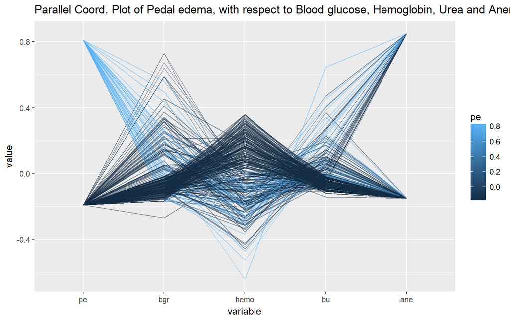

```r
variables1 <- c("pe", "bgr", "hemo", "bu", "ane")

ckd2 %>%
  select(variables1) %>%   ggparcoord(alpha = .5, scale = "center", columns = 1:5, groupColumn = "pe", title = "Parallel Coord. Plot of Pedal edema, with respect to Blood glucose, Hemoglobin, Urea and Anemia")
```

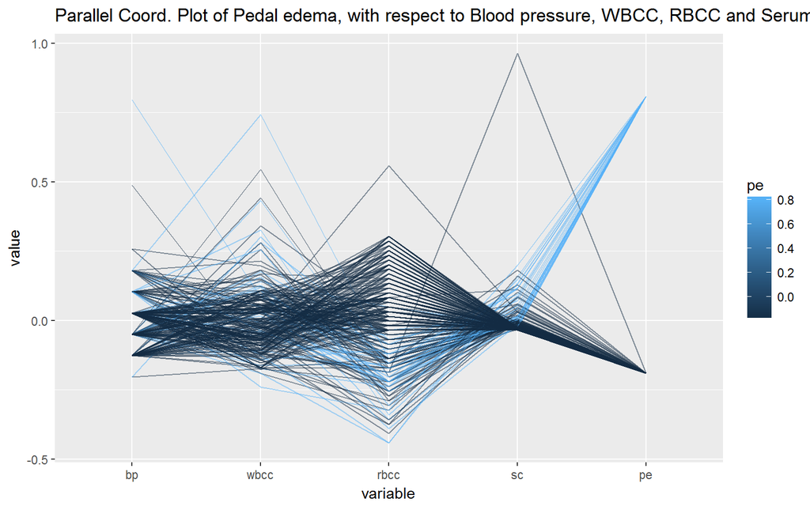

```r
variables2 <- c("bp", "wbcc", "rbcc", "sc", "pe")

ckd2 %>%
select(variables2) %>%   ggparcoord(alpha = .5, scale = "center", columns = 1:5, groupColumn = "pe", title = "Parallel Coord. Plot of Pedal edema, with respect to Blood pressure, WBCC, RBCC and Serum creatinine")
```

The parallel coordination plot is a very interesting way to visualize even 4-5 variables in a single plot. This graph, particularly, gives a description of how the different values are varying when it comes to Pedal edema. Patients with pedal edema generally have a lower rbc count and hemoglobin level, while for all the other factors, it was pretty mixed. There might be some relation between the RBC and hemoglobin vs the pedal edema.

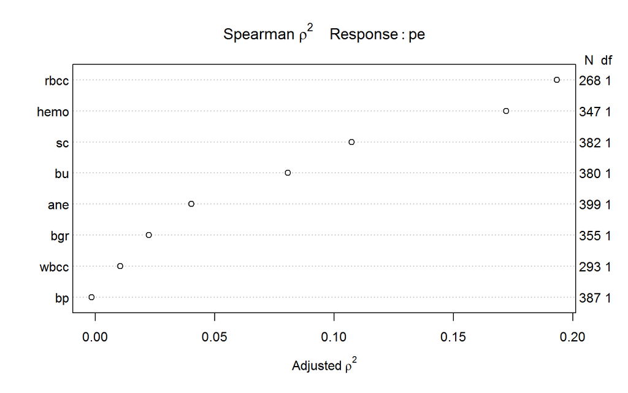

```r
plot(spearman2(pe ~ hemo + ane + bgr + bu + bp + wbcc + rbcc + sc, data = ckd2))
```

According to the spearman rho squared plot, rbc count has the highest predictive power, followed by hemoglobin levels, which is a close second, which is to be expected. The others are serum creatinine, blood urea, and anemia. I thus, decided to use the first 5 variables from the plot to make my non linear model.

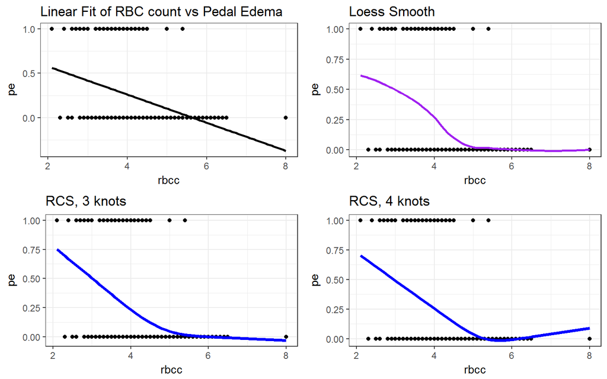

```r
mod1 <- lm(pe~rcs(rbcc, 3), data = ckd2)
mod2 <- lm(pe~rcs(rbcc, 4), data = ckd2)
mod1.aug <- augment(mod1, ckd2)
mod2.aug <- augment(mod2, ckd2)

p1 <- ggplot(ckd2, aes(x = rbcc, y = pe)) +
     geom_point() +
     geom_smooth(method = "lm", col = "black", se = F) +
     labs(title = "Linear Fit of RBC count vs Pedal Edema ") +
     theme_bw()

p2 <- ggplot(ckd2, aes(x = rbcc, y = pe)) +
     geom_point() +
     geom_smooth(method = "loess", col = "purple", se = F) +
     labs(title = "Loess Smooth") +
     theme_bw()

p3 <- ggplot(mod1.aug, aes(x = rbcc, y = pe)) +
          geom_point() +
         geom_line(aes(x = rbcc, y = .fitted),
               col = "blue", size = 1.25) +
        labs(title = "RCS, 3 knots") +
        theme_bw()

p4 <- ggplot(mod2.aug, aes(x = rbcc, y = pe)) +
            geom_point() +
           geom_line(aes(x = rbcc, y = .fitted),
            col = "blue", size = 1.25) +
          labs(title = "RCS, 4 knots") +
         theme_bw()

gridExtra::grid.arrange(p1, p2, p3, p4, nrow = 2)
```

This plot is about the splines, and how good do different polynomial or linear lines fit the distribution of rbc count and pedal edema. A lot of values were removed from the graph, because they were missing.  
I chose to go forward with the spline with 4 knots, especially since there isn’t a major difference in the graphs with 3 and 4 knots.

## 5.2 Model 1

```r
m_imp_model1 <-
    fit.mult.impute(pe ~ rcs(rbcc, 4) + hemo +
                        sc + bu + ane,
                    fitter = lrm, xtrans = multi,
                    data = ckd2, x = T, y = T)
```

```
Variance Inflation Factors Due to Imputation:

Intercept      rbcc     rbcc'    rbcc''      hemo        sc        bu
     1.64      1.71      1.62      1.57      1.34      1.06      1.07
      ane
     1.17

Rate of Missing Information:

Intercept      rbcc     rbcc'    rbcc''      hemo        sc        bu
     0.39      0.42      0.38      0.36      0.26      0.06      0.07
      ane
     0.14

d.f. for t-distribution for Tests of Single Coefficients:

Intercept      rbcc     rbcc'    rbcc''      hemo        sc        bu
    59.58     51.81     61.44     67.79    137.21   2538.16   1974.95
      ane
   430.70

The following fit components were averaged over the 10 model fits:

  stats linear.predictors
```

```r
m_imp_model1
```

```
Logistic Regression Model

 fit.mult.impute(formula = pe ~ rcs(rbcc, 4) + hemo + sc + bu +
     ane, fitter = lrm, xtrans = multi, data = ckd2, x = T, y = T)

                        Model Likelihood     Discrimination    Rank Discrim.
                           Ratio Test           Indexes           Indexes
 Obs            400    LR chi2      99.71    R2       0.355    C       0.836
  0             323    d.f.             7    g        1.881    Dxy     0.672
  1              77    Pr(> chi2) <0.0001    gr       6.606    gamma   0.672
 max |deriv| 0.0004                          gp       0.209    tau-a   0.208
                                             Brier    0.117

           Coef    S.E.    Wald Z Pr(>|Z|)
 Intercept -0.0502  2.4362 -0.02  0.9836
 rbcc       0.1460  0.6963  0.21  0.8339
 rbcc'     -4.4958  2.1501 -2.09  0.0365
 rbcc''    18.2297 10.3175  1.77  0.0773
 hemo      -0.0863  0.1341 -0.64  0.5198
 sc        -0.0331  0.0343 -0.97  0.3340
 bu         0.0077  0.0039  1.99  0.0470
 ane       -0.5474  0.4482 -1.22  0.2220
```

This model utilizes 4 knots and 5 variables, and spends 7 degrees of freedom. The Nagelkerke R square value was found to be 0.35, with the C-statistic = 0.836, which tells us that this model has good discrimination between patients having pedal edema and patients not having pedal edema.

### 5.2.1 Anova

```r
anova(m_imp_model1)
```

```
                Wald Statistics          Response: pe

 Factor     Chi-Square d.f. P
 rbcc       11.77      3    0.0082
  Nonlinear  4.97      2    0.0835
 hemo        0.41      1    0.5198
 sc          0.93      1    0.3340
 bu          3.95      1    0.0470
 ane         1.49      1    0.2220
 TOTAL      51.16      7    <.0001
```

### 5.2.2 Summary

```r
summary(m_imp_model1)
```

```
             Effects              Response : pe

 Factor      Low  High Diff. Effect    S.E.     Lower 0.95 Upper 0.95
 rbcc         3.9  5.4  1.5  -2.848700 0.831100 -4.4776000 -1.219700
  Odds Ratio  3.9  5.4  1.5   0.057922       NA  0.0113610  0.295310
 hemo        10.3 15.0  4.7  -0.405600 0.630180 -1.6407000  0.829530
  Odds Ratio 10.3 15.0  4.7   0.666580       NA  0.1938400  2.292200
 sc           0.9  2.8  1.9  -0.062900 0.065112 -0.1905200  0.064718
  Odds Ratio  0.9  2.8  1.9   0.939040       NA  0.8265300  1.066900
 bu          27.0 66.0 39.0   0.298740 0.150400  0.0039552  0.593520
  Odds Ratio 27.0 66.0 39.0   1.348200       NA  1.0040000  1.810400
 ane          0.0  1.0  1.0  -0.547390 0.448250 -1.4259000  0.331160
  Odds Ratio  0.0  1.0  1.0   0.578460       NA  0.2402800  1.392600
```

### 5.2.3 Calibration and validation

```r
exp(coef(m_imp_model1))
```

```
   Intercept         rbcc        rbcc'       rbcc''         hemo
9.510613e-01 1.157239e+00 1.115587e-02 8.261668e+07 9.173218e-01
          sc           bu          ane
9.674366e-01 1.007689e+00 5.784596e-01
```

```r
glance(m_imp_model1)
```

```
  s[c("null.deviance", "df.null")]    logLik      AIC      BIC deviance
1                               NA -147.1669 310.3337 342.2655 391.8622
2                               NA -147.1669 310.3337 342.2655 294.3337
```

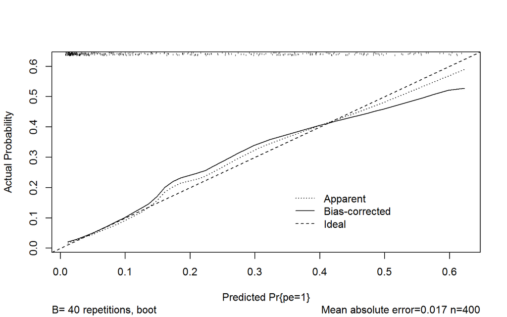

```
n=400   Mean absolute error=0.017   Mean squared error=0.00063
0.9 Quantile of absolute error=0.04
```

```r
plot(calibrate(m_imp_model1))
```

```r
validate(m_imp_model1)
```

```
Divergence or singularity in 1 samples
```

```
          index.orig training    test optimism index.corrected  n
Dxy           0.6608   0.6724  0.6468   0.0256          0.6352 39
R2            0.3545   0.3598  0.3295   0.0303          0.3242 39
Intercept     0.0000   0.0000 -0.0471   0.0471         -0.0471 39
Slope         1.0000   1.0000  0.9278   0.0722          0.9278 39
Emax          0.0000   0.0000  0.0247   0.0247          0.0247 39
D             0.2468   0.2508  0.2280   0.0228          0.2240 39
U            -0.0050  -0.0050  0.0016  -0.0066          0.0016 39
Q             0.2518   0.2558  0.2263   0.0294          0.2223 39
B             0.1183   0.1146  0.1219  -0.0073          0.1256 39
g             1.8810   1.8533  1.6915   0.1618          1.7192 39
gp            0.2089   0.2085  0.2030   0.0054          0.2034 39
```

### 5.2.4 Nomogram

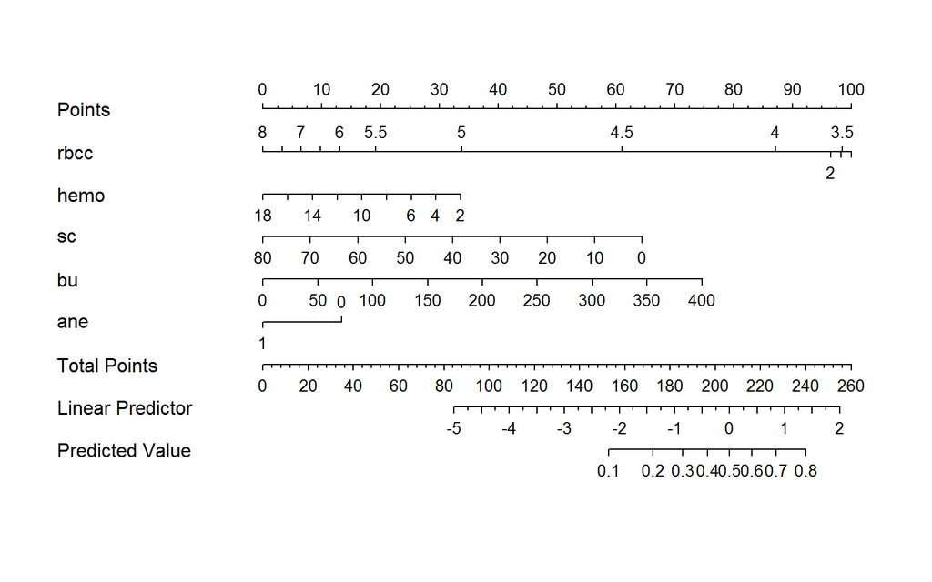

```r
plot(nomogram(m_imp_model1, fun = plogis))
```

The Brier value is 0.117, indicating that the model is calibrated pretty well, with the calibration plot showing Mean absolute error=0.017, and Mean squared error=0.00063. As the predicted probability of pedal edema goes higher, initially, the calibration s such that the actual probability of one having pedal edema is slightly higher, while after a certain point, the actual probability goes below the predicted probability.

The AIC and BIC values are: 310.33 and 342.26 respectively.

Thus, according to the nomogram, and the p value, RBC count is the most important factor for prediction of pedal edema.

## 5.3 Model 2 (Kitchen sink)

```r
m_imp_model2 <-
    fit.mult.impute(pe ~ rbcc + hemo + bgr +
                        sc + bu + ane + wbcc + bp ,
                   fitter = lrm, xtrans = multi,
                   data = ckd2, x = T, y = T)
```

```
Variance Inflation Factors Due to Imputation:

Intercept      rbcc      hemo       bgr        sc        bu       ane
     1.25      1.71      1.38      1.07      1.04      1.04      1.13
     wbcc        bp
     1.72      1.04

Rate of Missing Information:

Intercept      rbcc      hemo       bgr        sc        bu       ane
     0.20      0.41      0.27      0.07      0.04      0.04      0.11
     wbcc        bp
     0.42      0.04

d.f. for t-distribution for Tests of Single Coefficients:

Intercept      rbcc      hemo       bgr        sc        bu       ane
   225.46     52.31    120.21   1900.49   5156.07   5111.29    701.90
     wbcc        bp
    51.03   5763.91

The following fit components were averaged over the 10 model fits:

  stats linear.predictors
```

```r
m_imp_model2
```

```
Logistic Regression Model

 fit.mult.impute(formula = pe ~ rbcc + hemo + bgr + sc + bu +
     ane + wbcc + bp, fitter = lrm, xtrans = multi, data = ckd2,
     x = T, y = T)

                       Model Likelihood     Discrimination    Rank Discrim.
                          Ratio Test           Indexes           Indexes
 Obs           400    LR chi2      99.22    R2       0.353    C       0.841
  0            323    d.f.             8    g        1.747    Dxy     0.681
  1             77    Pr(> chi2) <0.0001    gr       5.781    gamma   0.681
 max |deriv| 0.001                          gp       0.207    tau-a   0.210
                                            Brier    0.116

           Coef    S.E.   Wald Z Pr(>|Z|)
 Intercept  4.6248 1.7570  2.63  0.0085
 rbcc      -1.0401 0.4233 -2.46  0.0140
 hemo      -0.1584 0.1340 -1.18  0.2373
 bgr        0.0001 0.0018  0.08  0.9399
 sc        -0.0259 0.0347 -0.75  0.4554
 bu         0.0073 0.0039  1.90  0.0571
 ane       -0.8100 0.4531 -1.79  0.0738
 wbcc       0.0001 0.0001  1.80  0.0711
 bp        -0.0141 0.0113 -1.25  0.2097
```

This model utilizes 8 variables, and spends 8 degrees of freedom. The Nagelkerke R square value was found to be 0.353, with the C-statistic = 0.841, which tells us that this model has good discrimination between patients having pedal edema and patients not having pedal edema, just like model 1.

### 5.3.1 Anova

```r
anova(m_imp_model2)
```

```
                Wald Statistics          Response: pe

 Factor     Chi-Square d.f. P
 rbcc        6.04      1    0.0140
 hemo        1.40      1    0.2373
 bgr         0.01      1    0.9399
 sc          0.56      1    0.4554
 bu          3.62      1    0.0571
 ane         3.20      1    0.0738
 wbcc        3.26      1    0.0711
 bp          1.57      1    0.2097
 TOTAL      49.59      8    <.0001
```

RBC count is the only variable with p value < 0.05, which tells us that rbc count is the only variable having a significant effect on log odds of Pedal edema.

### 5.3.2 Summary

```r
summary(m_imp_model2)
```

```
             Effects              Response : pe

 Factor      Low    High   Diff.  Effect     S.E.     Lower 0.95
 rbcc           3.9    5.4    1.5 -1.5602000 0.635000 -2.8048000
  Odds Ratio    3.9    5.4    1.5  0.2101000       NA  0.0605210
 hemo          10.3   15.0    4.7 -0.7444500 0.629910 -1.9790000
  Odds Ratio   10.3   15.0    4.7  0.4750000       NA  0.1382000
 bgr           99.0  163.0   64.0  0.0086714 0.114960 -0.2166400
  Odds Ratio   99.0  163.0   64.0  1.0087000       NA  0.8052200
 sc             0.9    2.8    1.9 -0.0492440 0.065974 -0.1785500
  Odds Ratio    0.9    2.8    1.9  0.9519500       NA  0.8364800
 bu            27.0   66.0   39.0  0.2860900 0.150400 -0.0086792
  Odds Ratio   27.0   66.0   39.0  1.3312000       NA  0.9913600
 ane            0.0    1.0    1.0 -0.8100000 0.453110 -1.6981000
  Odds Ratio    0.0    1.0    1.0  0.4448600       NA  0.1830300
 wbcc        6500.0 9800.0 3300.0  0.3408800 0.188870 -0.0293000
  Odds Ratio 6500.0 9800.0 3300.0  1.4062000       NA  0.9711200
 bp            70.0   80.0   10.0 -0.1413400 0.112670 -0.3621800
  Odds Ratio   70.0   80.0   10.0  0.8681900       NA  0.6961600
 Upper 0.95
 -0.315600
  0.729350
  0.490140
  1.632600
  0.233990
  1.263600
  0.080062
  1.083400
  0.580870
  1.787600
  0.078088
  1.081200
  0.711050
  2.036100
  0.079496
  1.082700
```

### 5.3.3 Calibration and Validation

```r
glance(m_imp_model2)
```

```
  s[c("null.deviance", "df.null")]    logLik      AIC     BIC deviance
1                               NA -144.0374 306.0748 341.998 391.8622
2                               NA -144.0374 306.0748 341.998 288.0748
```

```r
exp(coef(m_imp_model2))
```

```
  Intercept        rbcc        hemo         bgr          sc          bu
101.9782637   0.3534117   0.8535139   1.0001355   0.9744151   1.0073627
        ane        wbcc          bp
  0.4448591   1.0001033   0.9859654
```

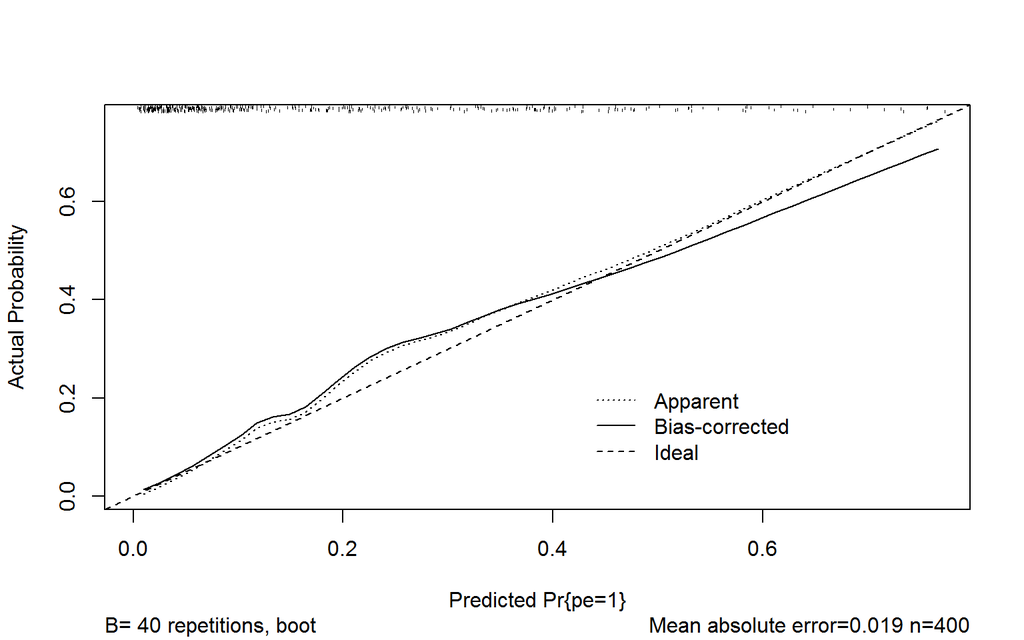

```
n=400   Mean absolute error=0.019   Mean squared error=0.00067
0.9 Quantile of absolute error=0.05
```

```r
plot(calibrate(m_imp_model2))
```

```r
validate(m_imp_model2)
```

```
          index.orig training    test optimism index.corrected  n
Dxy           0.6803   0.7025  0.6697   0.0328          0.6475 40
R2            0.3529   0.3875  0.3426   0.0449          0.3080 40
Intercept     0.0000   0.0000 -0.1157   0.1157         -0.1157 40
Slope         1.0000   1.0000  0.9005   0.0995          0.9005 40
Emax          0.0000   0.0000  0.0445   0.0445          0.0445 40
D             0.2456   0.2767  0.2383   0.0383          0.2072 40
U            -0.0050  -0.0050  0.0023  -0.0073          0.0023 40
Q             0.2506   0.2817  0.2360   0.0457          0.2049 40
B             0.1153   0.1118  0.1186  -0.0068          0.1221 40
g             1.7469   1.8670  1.6700   0.1970          1.5500 40
gp            0.2074   0.2184  0.2051   0.0133          0.1941 40
```

The Brier value is 0.116, slightly lesser than model 1, but not enough to make a difference.The calibration plot shows Mean absolute error=0.019, and Mean squared error=0.00067, which is slightly higher than model1, but gain, not enough to make a big difference. The calibration plot shows that the actual probability of one having pedal edema is slightly higher than the predicted probability, while after a certain point, the actual probability goes below the predicted probability.

The AIC and BIC values are: 306.07 and 341.99 respectively, so, slightly lower than model 1.

### 5.3.4 Nomogram

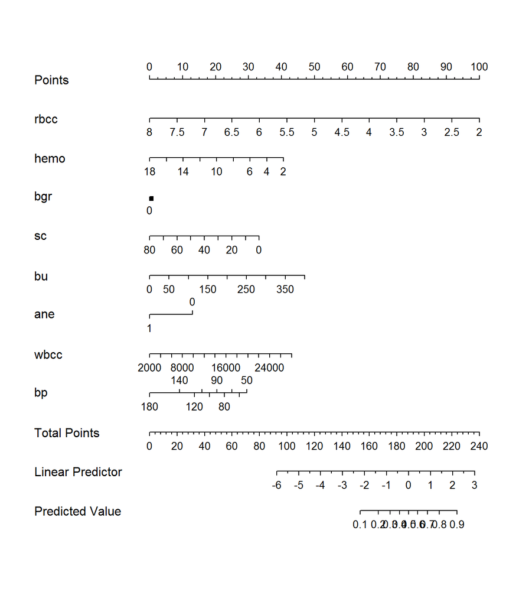

```r
plot(nomogram(m_imp_model2, fun = plogis))
```

The nomogram shows how significant the RBC count is in order to determine Pedal edema.

## 5.4 Comparisons between the two models

| Parameter | Value in Model 1 | Value in Model 2 |
| --- | --- | --- |
| `Nagelkerke R square` | 0.355 | 0.353 |
| `C statistic` | 0.836 | 0.841 |
| `AIC` | 310.33 | 306.07 |
| `BIC` | 342.26 | 341.98 |
| `Brier Score` | 0.117 | 0.116 |
| `Mean Squared Error` | 0.00063 | 0.00067 |
| `Mean Absolute Error` | 0.017 | 0.019 |
| `Degrees of freedom` | 7 | 8 |

# 6 Conclusions

Irrespective of the model, RBC count is the most important factor for prediction of pedal edema, and the people with lower RBC values are at higher risk for pedal edema. This is what I wanted to find out, since people with abnormally lower count of RBCs can be warned of developing pedal edema or venous thrombosis, thus enabling us to take preventive measures on time. Another conclusion to take home was that neither hemoglobin nor creatinine aren’t major players in assessing risk of pedal edema, though they do contribute something, so there must be another protein in the blood which is highly indicative of occurring of Edema.

Multiple imputation can be really confusing, and combining it with Non linear plots and Logistic regression increases the said confusion. I had a lot of trouble with it, since I couldn’t do Stepwise Regression, and had to make a kitchen sink model for comparison. The confidence intervals are too not being generated for the models.I did get some pretty good visualization tools this time, which I wish I’d got earlier. The parallel coordination plot is an amazing way of representation for multiple variables.

Satyakam Mishra

2018-05-08 19:13:39